# Table of Contents

梁时婧 11712638

# Assignment 3

```python
import numpy as np
import pandas as pd
import matplotlib.pyplot as plt
%matplotlib inline
import gc
```

## Question 1

Write brief descriptions for the weather conditions at each of the following three sites. Include all information offered in the weather symbols.

**Figure 1**

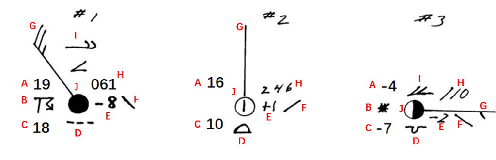

A - Temperature  
B - Present Weather  
C - Dew Point  
D - Low Cloud Type  
E - Pressure Change  
F - Pressure Tendency  
G - Wind Speed and Direction  
H - Barometric Pressure  
I - High Cloud Type  
J - Cloud Coverage

Elements are described from A-I

**Figure 2:** temperature 16℃; dew point 10℃; low cloud Fair Weather Cumulus; increasing pressure for 1 unit; pressure higher than three hours ago and rising steadily; North wind with speed less than 5 knots; 1024.6 mb; 1/10 cloud coverage

**Figure 3:** temperature -4℃; intermittent light snow; dew point -7℃; low cloud Stratocumulus; decreasing pressure for 2 unit; pressure lower than three hours ago and falling steadily; East wind with speed of 5 knots; 1011.0 mb; mid-level cloud Thick Altocumulus; 1/2 cloud coverage

## Question 2

Select an automated meteorological station of your choice. Select a date and a time and take screenshots of the weather monitoring data of that station. Plot the weather symbol for that station at that time.

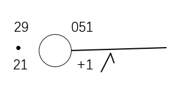

[figure not shown]

**Calculation of the dew point**

$ln\frac{e_s(hPa)}{6.11} \approx\ 5420 \cdot\ (\frac{1}{273}-\frac{1}{T})$

The surface temperature: $T = 28.9℃ = 301.9 K$  
The saturation vapor pressure under this surface temperature is

$e_s = 40.87 hPa$

According to the relative humidity

$RH = \frac{e}{e_s(T)} \cdot 100$% = 62

The vapor pressure is calculated: 25.34 hPa  
The dew point is calculated when the saturation vapor pressure reaches $e'_s = 25.34 hPa$

$T_d = 294.07 K = 21.07℃$

## Question 3

Manually draw the windrose at this station, dividing the wind directions into 12 sectors (30 degrees per direction).

```python
q3_file = pd.ExcelFile('MetClim/windrose.xlsx')
df = q3_file.parse('Sheet3', index_col=0)
df # Accumulated probability
```

| Range | 0-20 | 30-50 | 60-80 | 90-110 | 120-140 | 150-170 | 180-200 | 210-230 | 240-260 | 270-290 | 300-320 | 330-350 |
| --- | --- | --- | --- | --- | --- | --- | --- | --- | --- | --- | --- | --- |
| 1.3 - 2 | 1.0 | 0.2 | 0.0 | 0.1 | 0.0 | 0.2 | 0.4 | 0.8 | 0.2 | 1.3 | 0.9 | 0.6 |
| 2 - 4 | 4.0 | 9.1 | 2.7 | 2.4 | 0.8 | 0.3 | 1.9 | 2.4 | 3.9 | 4.0 | 4.3 | 1.6 |
| 4 - 6 | 4.1 | 19.5 | 11.2 | 6.7 | 2.2 | 0.6 | 2.0 | 3.5 | 7.3 | 7.6 | 5.6 | 1.7 |
| 6 - 8 | 0.0 | 26.0 | 20.0 | 7.9 | 0.0 | 0.7 | 0.0 | 0.0 | 8.6 | 9.7 | 5.7 | 0.0 |
| 8 - 10 | 0.0 | 27.7 | 20.8 | 0.0 | 0.0 | 0.0 | 0.0 | 0.0 | 8.7 | 9.9 | 0.0 | 0.0 |
| 10 - 12 | 0.0 | 0.0 | 21.1 | 0.0 | 0.0 | 0.0 | 0.0 | 0.0 | 0.0 | 0.0 | 0.0 | 0.0 |

[output not shown]

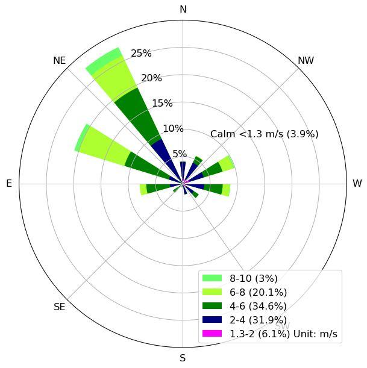

```python
N = 12
theta = np.linspace(0.0, 2 * np.pi,N, endpoint=True)
width = np.pi/N
plt.figure(figsize=(8,8),dpi=90)
ax = plt.subplot(111, projection='polar')

ax.set_yticks(ax.get_yticks())
ax.set_yticklabels(['5%','10%','15%','20%','25%'],fontsize=13)
ax.set_theta_zero_location('N')
ax.set_thetagrids([0,45,90,135,180,215,270,315,360],
                  ['N','NE','E','SE','S','SW','W','NW'],fontsize=13)

ax.bar(theta,df.loc['   8 -   10'],width=width,color='lime',alpha=0.6)
ax.bar(theta,df.loc['   6 -    8'],width=width,color='greenyellow')
ax.bar(theta,df.loc['   4 -    6'],width=width,color='g')
ax.bar(theta,df.loc['   2 -    4'],width=width,color='navy')
ax.bar(theta,df.loc[' 1.3 -    2'],width=width,color='magenta')

ax.legend(['8-10 (3%)','6-8 (20.1%)','4-6 (34.6%)','2-4 (31.9%)','1.3-2 (6.1%) Unit: m/s'],
          loc='lower right',fontsize=13)

ax.text(100,10,'Calm <1.3 m/s (3.9%)',fontsize=13)
```

## Question 4

**(a) Plot the barometric law (atmospheric pressure as a function of altitude) from the surface to 15 km, assuming the scale height of the lower atmosphere is 6.7 km and the surface pressure is 1013.25 hPa.**

```python
H = 6.7 # Scale height
p0 = 1013.25 # Unit: hPa
z = np.linspace(0,15,25) # altitude

# Define the Barometric equation
def Barometric_pz(z):
    p_z = p0*np.exp((-1/H)*z)
    return p_z
# return pressure

def Barometric_h(p):
    z = np.log((p/p0))*(-H)
    return z
# return altitude
```

```python
p_z = Barometric_pz(z)
p_z
```

```
array([1013.25      ,  923.00502936,  840.79771451,  765.91218275,
        697.69632048,  635.55609452,  578.95037916,  527.38624399,
        480.41466135,  437.62659621,  398.64944415,  363.14378673,
        330.80043576,  301.33774085,  274.49913678,  250.05090926,
        227.78015973,  207.49295141,  189.01262049,  172.17823767,
        156.84320683,  142.87398838,  130.14893643,  118.55723947,
        107.99795539])
```

**(b) What is the corresponding altitudes for the following pressure levels: (b) 850 hPa; (c) 700 hPa; (d) 500 hPa; (e) 200 hPa.**

Figure for question (a)

(b) The corresponding altidues for

(1) 850 hPa: 1.18 km

(2) 700 hPa: 2.48 km

(3) 500 hPa: 4.73 km

(4) 200 hPa: 10.87 km

```python
p = np.array((850,700,500,200))
z1 = Barometric_h(p)
z1
```

```
array([ 1.17706884,  2.47791413,  4.73227812, 10.87142602])
```

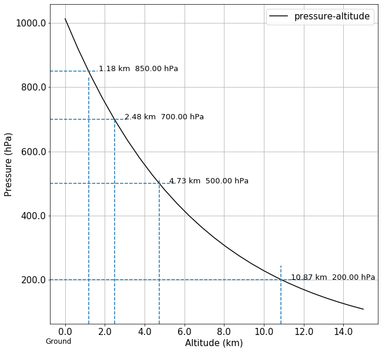

```python
fig,ax = plt.subplots(figsize=(10,10))
ax.plot(z,p_z,color='k')
ax.set_xticklabels(ax.get_xticks(),fontsize=15)
ax.set_yticklabels(ax.get_yticks(),fontsize=15)
ax.text(-1,0,'Ground',fontsize=12)
ax.set_xlabel('Altitude (km)',fontsize=15)
ax.set_ylabel('Pressure (hPa)',fontsize=15)
for i in range(len(z1)):
    ax.axhline(p[i],xmax=(z1[i]+1)/15,linestyle='--')
    ax.axvline(z1[i],ymax=p[i]/1100,linestyle='--')
    ax.text(z1[i]+0.5,p[i],'%.2f km'%z1[i]+'  %.2f hPa'%p[i],fontsize=13)

ax.legend(['pressure-altitude'],fontsize=15)
ax.grid()
```

## Question 5

**(a) Draw the dry and moist adiabatic temperature profiles on a (T-p or T-z plot). Also draw, schematically, the ambient atmospheric temperature and dew point temperature profiles during a strong thunderstorm (i.e., a very strong convection).**

The dry sdiabatic lapse rate is described as follow:

$-(\frac{dT}{dz})_{dry parcel} = \frac{g}{c_p} = \Gamma_d = 9.8 K km^{-1}$

The saturated adiabatic lapse rate $\Gamma_s$ varies with pressure and temperature, but it follows that

$\Gamma_s < \Gamma_d$.

Here, we chose the saturated adiabatic lapse rate $\Gamma_s$ to be $6.2 K km^{-1}$  
The lapse rate for the ambient air is chosen to be $10.5 K km^{-1}$

```python
# Clausius-Clayperon equation
# Calculating the saturation vapor pressure
def cc_es(T):
    es = 6.11*np.exp(5420*((1/273)-(1/(273+T))))
    return es
```

[output not shown]

[figure not shown]

```python
fig,ax = plt.subplots(figsize=(10,10))

z = np.linspace(0,3.5,20)  # Altitude unit:km
p = Barometric_pz(z)       # Pressure unit:hPa
t0 = np.linspace(32,32,20) # Temperature unit: Celise degrees

t_d = t0 - 9.8*z # Dry lapse rate
t_s = t0 - 6.2*z # Moist lapse rate
t_a = t0-10.5*z  # Ambient lapse rate
t_d[:10] = t_a[:10]-2 # Dew Point
t_d[10:] = t0[10:] - 6.2*z[10:]

ax.set_xlim(0,30)
ax.set_ylim(0,3.5)
ax.set_xlabel('Temperature (℃)',fontsize=18)
ax.set_ylabel('Altitude (km)',fontsize=18)
ax.set_xticklabels(ax.get_xticks(),fontsize=18)
ax.set_yticklabels(ax.get_yticks(),fontsize=18)

ax.plot(t_d,z,'--',color='salmon',lw=3.5)
ax.plot(t_s,z,'--',color='navy',lw=3.5)
ax.plot(t_a,z,color='k',lw=3)

ax.legend(['Dry lapse rate','Moist lapse rate','Ambient lapse rate','Dew Point'],fontsize=16)

ax.annotate('Segment 1',xy=(15,1.4),xytext=(14,0.8),
            arrowprops=dict(facecolor='k',shrink=0.01),fontsize=18)
ax.annotate('Segment 2',xy=(19,2.2),xytext=(21,2.5),
            arrowprops=dict(facecolor='k',shrink=0.01),fontsize=18)
```

**(b) Briefly explain your drawing.**

**Segment 1: the dew point line is lower than the ambient air lapse rate line (the black line)**

As the air parcel rises, it cooles down but cannot reach the dew point and it is still insaturated.

**Segment 2: the dew point line is overlapping with the moist lapse rate line (the darkblue line)**  
The air parcel continues rising and cools following the moist lapse rate, and it becomes saturated and reaches the dew point. At this time, there is possibility to have precipitation event.

## Question 6

Data is downloaded from http://weather.uwyo.edu/cgi-bin/sounding?region=seasia&TYPE=TEXT%3ALIST&YEAR=2020&MONTH=10&FROM=1800&TO=1800&STNM=45004

Site: 45004 Kings Park Observations at 00Z 18 Oct 2020

**(a) Use python to plot the vertical profiles of temperature and dew point temperature as a function of altitude.**

```python
# Open file for question (a)
file = pd.ExcelFile('MetClim/Wyoming.xlsx')
df = file.parse('Sheet1', index_col=1)

# Open file for question (b)
q1_file = pd.ExcelFile('MetClim/ATM.xlsx')
df1 = q1_file.parse('Sheet1', index_col=0)
df, df1
```

| HGHT | PRES | TEMP | DWPT | RELH | MIXR | DRCT | SKNT | THAT | THTE | THTV |
| --- | --- | --- | --- | --- | --- | --- | --- | --- | --- | --- |
| 66 | 1009.0 | 22.0 | 17.0 | 73 | 12.22 | 0 | 0 | 294.4 | 329.6 | 296.6 |
| 141 | 1000.0 | 21.4 | 16.4 | 73 | 11.87 | 30 | 6 | 294.6 | 328.7 | 296.6 |
| 342 | 977.0 | 20.2 | 15.8 | 75 | 11.64 | 70 | 10 | 295.3 | 329.0 | 297.4 |
| 785 | 928.0 | 17.6 | 14.3 | 81 | 11.16 | 75 | 31 | 297.0 | 329.6 | 299.0 |
| 813 | 925.0 | 17.6 | 14.3 | 81 | 11.19 | 75 | 31 | 297.3 | 330.0 | 299.3 |
| ... | ... | ... | ... | ... | ... | ... | ... | ... | ... | ... |
| 18389 | 73.0 | -78.3 | -89.2 | 16 | 0.00 | 95 | 10 | 411.7 | 411.7 | 411.7 |
| 18397 | 72.9 | -78.3 | -89.3 | 16 | 0.00 | 97 | 10 | 411.8 | 411.8 | 411.8 |
| 18468 | 72.0 | -77.5 | -89.1 | 14 | 0.00 | 115 | 10 | 414.9 | 414.9 | 414.9 |
| 18630 | 70.0 | -75.7 | -88.7 | 12 | 0.00 | 145 | 6 | 422.1 | 422.1 | 422.1 |
| 19344 | 62.0 | -70.3 | -91.2 | 3 | 0.00 | 160 | 10 | 448.9 | 448.9 | 448.9 |

88 rows × 10 columns

[figure not shown]

```python
fig,ax = plt.subplots(figsize=(7,9))

ax.set_xlabel('Temperature (℃)',fontsize=16)
ax.set_ylabel('Altitude (km)',fontsize=16)
xtick = np.arange(-100,41,20)
ax.set_xticks(xtick)
ax.set_xticklabels(xtick,fontsize=14)
ax.set_yticks(np.arange(2000,30000,2500))
ax.set_yticklabels(np.arange(2,20,2.5),fontsize=14)
ax.set_ylim(0,20000)
ax.grid()

ax.plot(df.TEMP,df.index,color='cornflowerblue',lw=2)
ax.plot(df.DWPT,df.index,color='salmon',lw=2)
ax.plot(df1['Temperature(K)']-273.15,df1.index,color='darkgrey',lw=3)

ax.legend(['ISA','Dew point','TEMP (Sounding)'],fontsize=14)
ax.text(-90,700,'45004 Kings Park Observations at 00Z 18 Oct 2020')
```

**(b) Add to this plot the temperature profile from the International Standard Atmosphere (ISA) you plotted in Assignment 1. Compare the differences in temperature profiles between the ISA and the sounding of your choice. Briefly discuss why there is such a difference?**

The hypsometric equation decribes that  
$Z_2 - Z_1 = \frac{R_d\bar{T_v}}{g_0}ln(\frac{p_1}{p_2})$